# 07 Correlation

# (07) Correlation

## Preamble

```r
# Preamble

## Install Pacman
load.pac <- function() {

  if(require("pacman")){
    library(pacman)
  }else{
    install.packages("pacman")
    library(pacman)
  }

    pacman::p_load(xts, sp, gstat, ggplot2, rmarkdown, reshape2, ggmap,
                 parallel, dplyr, plotly, tidyverse, reticulate, UsingR, Rmpfr,
                 swirl, corrplot, gridExtra, mise, latex2exp, tree, rpart, lattice,
                 coin, primes, epitools, maps, clipr, ggmap, RColorBrewer)


   mise()
   select <- dplyr::select
}

load.pac()
```

```r
setwd(dir = "/home/ryan/Notes/DataSci/ThinkingAboutData/")
load(file = "~/Notes/DataSci/ThinkingAboutData/TAD.rdata")
load(file = "./TAD.rdata")
print("Success")
```

```
[1] "Success"
```

```r
knitr::opts_chunk$set(fig.path = "./figure/")
```

## Scatterplots

### Crabs

```r
crabsmolt %>%
    as_tibble
```

| presz | postsz |
| --- | --- |
| 113.6 | 127.7 |
| 118.1 | 133.2 |
| 119.9 | 135.3 |
| 126.2 | 143.3 |
| 126.7 | 139.3 |
| 127.3 | 140.2 |
| 128.2 | 143.8 |
| 129.5 | 144.6 |
| 130.5 | 147.6 |
| 131.6 | 144.8 |

[output cut: 462 more lines]

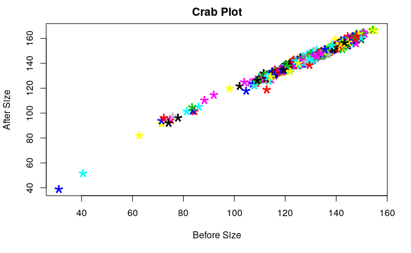

```r
plot(postsz ~ presz, data = crabsmolt,
     pch = "*", cex = 3, col = 1:15, main = "Crab Plot",
     xlab = "Before Size", ylab = "After Size")
```

This can also be plotted in `ggplot2`:

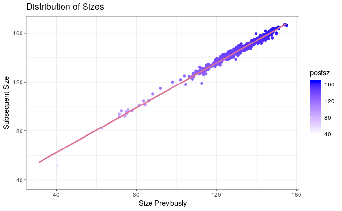

```r
#names(crabsmolt) %>% clipr::write_clip()

ggplot(crabsmolt, aes(x = presz, y = postsz)) +
    geom_point(aes(col = postsz)) +
    labs(x = "Size Previously", y = "Subsequent Size",
         title = "Distribution of Sizes") +
    stat_smooth(method = "lm", se = FALSE, col = "#Db7093" ) +
    scale_color_continuous(low = "white", high = "blue") +
    theme_bw()
```

### Pulse Data

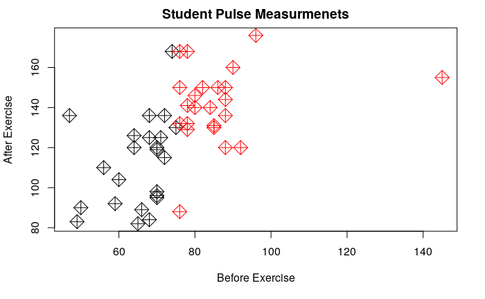

```r
plot(After ~ Before, data = PulseBA,
     main = "Student Pulse Measurmenets",
     xlab = "Before Exercise",
     ylab = "After Exercise",
     pch  = 9, cex = 2,
     col = (PulseBA$Before > mean(PulseBA$Before)) + 1)
```

```r
names(PulseBA)
```

```
[1] "Before" "After"
```

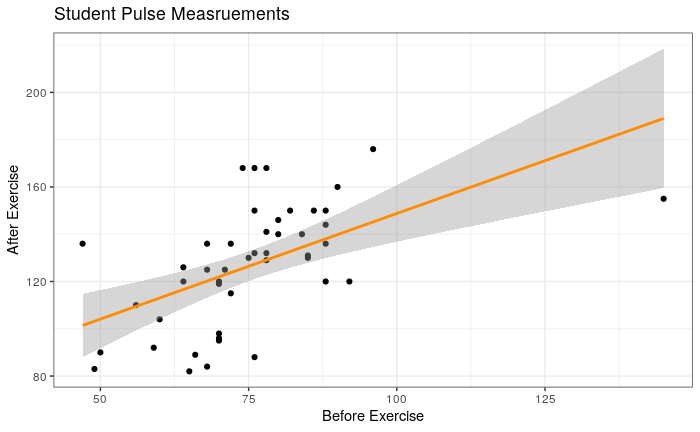

```r
ggplot(PulseBA, aes(x = Before, y = After)) +
    geom_point() +
    labs(x = "Before Exercise",
         y = "After Exercise",
         title = "Student Pulse Measruements") +
    stat_smooth(method = "lm", col = "#Ff8c00") +
    theme_bw()
```

### Earning Data

```r
heights %>%
    names()
```

```
[1] "earn"   "height" "gender" "age"    "eth"
```

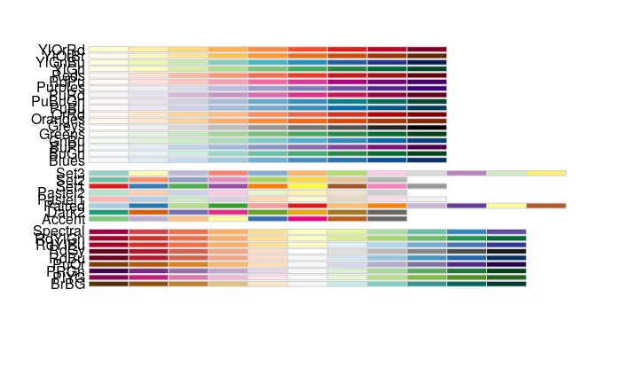

```r
## Alternatively Choose Colour Pallete
RColorBrewer::display.brewer.all()
```

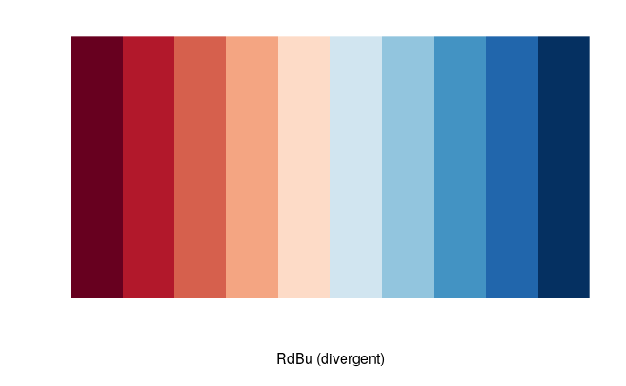

```r
display.brewer.pal(n = 10, "RdBu")
```

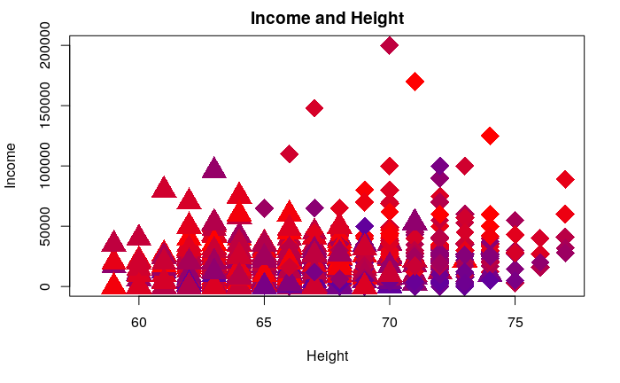

```r
cols <- RColorBrewer::brewer.pal(n = 10, "RdBu")

## Create a Diverging Pallette
pal <- colorRampPalette(c("blue", "red"))
cols <- pal(heights$age)

plot(earn ~ height, data = heights,
#     col = c("PeachPuff", "Violet")[heights$gender],
     col = cols[heights$age],
     xlab = "Height", ylab = "Income", main = "Income and Height",
     cex = 3,
     pch = c(17, 18)[heights$gender])
```

```r
# Create a legend
# legend(x = )
```

This is far easier to achieve in ggplot2:

```r
names(heights)
```

```
[1] "earn"   "height" "gender" "age"    "eth"
```

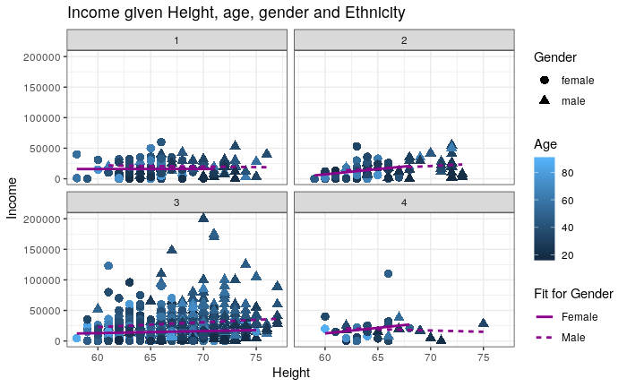

```r
heights$eth <- factor(heights$eth)

ggplot(heights, aes(x = height, y = earn)) +
    geom_point(size = 3, aes(shape = gender, col = age)) +
    labs(x = "Height", y = "Income",
         title = "Income given Height, age, gender and Ethnicity",
         col = "Age", shape = "Gender") +
    stat_smooth(se = FALSE, method = "lm", aes(group = gender, linetype = gender), col ="DarkMagenta" ) +
    scale_linetype_discrete(name = "Fit for Gender", labels = c("Female", "Male")) +
    facet_wrap(. ~ eth) +
    theme_bw()
```

## Correlation

### Crabs

The correlation coefficient is a measure of the strength of a relationship between two variables, 1 being a positive and -1 being a negative relationship: + The *Pearson Correlation Coefficient* is a measure of the strength of a linear relationship between variables + squaring this value returns the proportion of variance attributable to the linear model + A significant linear trend doesn’t mean that the rate of change is necessary meaningful, e.g. a model may show a mediction certainly increase your life by 1 ns, even though it’s guaranteed doesn’t mean that it matters. + The *Spearman Correlation Coefficient* is a measure of the strength of a monotone relationship between two variables.

```r
cor(crabsmolt$postsz, crabsmolt$presz, method = "pearson")
cor(crabsmolt$postsz, crabsmolt$presz, method = "spearman")
```

[output not shown]

This shows that there is a strong linear relationship between the size of a crab before and after molting.

### Earnings

```r
cor(heights$earn, heights$height, method = "pearson")
```

```
[1] 0.3023864
```

```r
cor(heights$earn, heights$height, method = "spearman")
```

```
[1] 0.3373793
```

This shows that there is a weak positive relationship between earnings and height

### Pulse Rate

```r
cor(PulseBA$Before, PulseBA$After, method = "pearson")
```

```
[1] 0.5484946
```

```r
cor(PulseBA$Before, PulseBA$After, method = "spearman")
```

```
[1] 0.652997
```

## Testing the Correlation Coefficient

### Crabs

In order to determine the p-value of a non-zero correlation coefficient, it is necessary to measure the False Positive rate from a simulation.

The simulation must be made under the circumstance that the null hypothesis is true, and then the number of False Positives measured:

- $H_0: \enspace \rho = 0$
- $H_a: \enspace \rho \neq 0$

The simulation would be:

```r
# What did we observe the correlation coefficient to be
r_obs <- cor(crabsmolt$postsz, crabsmolt$presz)

sim <- replicate(10^4, {
## What would we see by chance
    post_perm  <- sample(crabsmolt$postsz)
    r_sim      <- cor(post_perm, crabsmolt$presz)
    r_sim
## Is what we saw by chance bigger than our observation?
    ## i.e. Is Chance bigger than what we saw?
    abs(r_sim) > abs(r_obs)
})

mean(sim)
```

```
[1] 0
```

In this case, the rate of false positives, assuming the correlation coefficient is zero, is extremely small

Assuming that $\rho$ is zero, the number of times that a more extreme value would arise by chance, i.e. the probability of a false positive, is very small, returning 0 in 10, 000, hence the null hypothesis is rejected and it is concluded that the correlation between crabs before and after molting is significantly different from zero.

In order to measure the p-value it is necessary to simulate the number of times a false positive, given the observation, would arise under the assumption that the correlation is 0.

```r
r_obs <- cor(heights$earn, heights$height, method = "spearman")

sim <- replicate(10^4, {
    ## What would the Correlation coefficient be in a sample
    earn_perm <- sample(heights$earn)
    r_sim     <- cor(earn_perm, heights$height)

    ## Would this be larger than what we saw?
    abs(r_sim) > abs(r_obs)
        ## This is the number of times that 0 is sampled as large as obs
})

mean(sim)
```

```
[1] 0
```

The probability of observing a correlation coefficient as extreme as this, given that the true correlation is 0, is very small (measuring 0 in 10^4), hence the null hypothesis is rejected and it conceded that there is a significant difference.

### Pulse Rates

In order to measure the p-value of the pulse rates it is sufficient to measure the false positive rate of a large simulation. To acheive this measure the number of times a $\rho$ value returns a value at least as extreme as the observation when in fact there is no correlation given the data:

```r
r_obs <- cor(PulseBA$Before, PulseBA$After, method = "pearson")

sim <- replicate(10^4, {
  After_perm <- sample(PulseBA$After)
  r_sim <- cor(After_perm, PulseBA$Before, method = "pearson")
  abs(r_sim) > abs(r_obs)
})

mean(sim)
```

```
[1] 0
```

```r
r_obs <- cor(PulseBA$Before, PulseBA$After, method = "spearman")

sim <- replicate(10^4, {
  After_perm <- sample(PulseBA$After)
  r_sim <- cor(After_perm, PulseBA$Before, method = "spearman")
  abs(r_sim) > abs(r_obs)
})

mean(sim)
```

```
[1] 0
```

The number of false positives for a rho value significantly different from zero when it is in fact not is very small and hence the null hypothesis is rejected, hence concede that there is a correllation between the variables.

### What does the p-value measure

The p-value is:

- The probability of a false positve
- The probability of rejecting the null hypothesis when it is true
  - Different from the false discovery rate, beware of the *Base Rate Fallacy*

## Confidence Intervals

#### Theory

In order to create a confidence interval it is necessary to consider all the possible $\rho$ values resulting from all the possible samples from the population of all possible observations.

In order to simulate a confidence interval it is sufficient to simulate a population by resampling / bootstrapping the original sample and then create a sufficiently large distribution of $\rho$ values, thanks to statistical properties this will create a distribution with an expected distribution equivalent to the population.

An easier way to peform the bootstrapping and correlation at once is to create a sample from the choices in the original sample, where repetition is allowed and measure the correlation coefficient of this new sample; repeating this many times will peform the bootstrapping and measure the correlation in one step.

1. Bootstrap the Sample to create a population
2. Repeat the following many times
   1. Sample the Population
   2. Measure and record the Correlation
3. The quantiles of this new distribution will represent the confidence Intervals

#### Crabs

```r
n <- nrow(crabsmolt)

sim <- replicate(10^4, {
    index <- sample(1:n, size = n, replace = TRUE)
    df    <- crabsmolt[index,]
    cor(df[,1], df[,2])
})
quantile(sim, c(0.025, 0.0975))
```

```
     2.5%     9.75%
0.9880379 0.9890029
```

```r
n <- nrow(heights)

sim <- replicate(10^4,{
    index <- sample(1:n, size = n, replace = TRUE)
    cor(heights$height[index], heights$earn[index])
})
quantile(sim, c(0.05/2, 1-0.05/2))
```

```
     2.5%     97.5%
0.2542559 0.3508847
```

#### Pulse Rate(Pearson and Spearman, 90%)

In order to measure a confidence interval for the population correlation coefficient given this sample, create a resample with repetition to create a bootstrap population and then measure the correlation coefficient of various samples of this bootstrapped population, it is equivalent to simply resample with repetition the population to a sample of the same size and then measure the confidence interval repeatedly.

```r
n <- nrow(PulseBA)

sim <- replicate(10^4, {
 index <- sample(1:n, size = n, replace = TRUE)
 cor(PulseBA$Before[index], PulseBA$After[index], method = "pearson")
})
quantile(sim, c(0.1/2, 1-0.1/2))
```

```
       5%       95%
0.4258508 0.7108894
```

```r
sim <- replicate(10^4, {
 index <- sample(1:n, size = n, replace = TRUE)
 cor(PulseBA$Before[index], PulseBA$After[index], method = "spearman")
})
quantile(sim, c(0.1/2, 1-0.1/2))
```

```
       5%       95%
0.4817679 0.7782354
```